# jekyll-jupyter-notebook20260521-4584-p8sshp

This is part one of my analysis of the round of 16 match between France and Argentina at the 2018 FIFA World Cup. This match is especially memorable for me as football fan, because it was the first match between Lionel Mesi and Kylian Mbappe, signaling a change of guards between two football generations. It was also the first game of the knockout rounds and also the joint-highest scoring game of the whole tournament.

Benjamin Pavard also scored a spectacular goal in the 57th minute which would later be awarded the goal of the tournament. If you are unaware of the goal in question, have a look at the video [on YouTube](https://www.youtube.com/watch?v=Ov39iGAgEn4).

This part of the analysis will give a brief introduction to event data in football, and then provide an analysis of the shots and expected goals (xG) in the match, tactics and lineups, and lastly possession patterns.

```python
import polars as pl
from statsbombpy import sb

import mplsoccer as mpl
import matplotlib.pyplot as plt

import sys
sys.path.append("..")
sys.dont_write_bytecode = True

import warnings
warnings.filterwarnings("ignore")
```

```python
from utils.statics import figsize, PITCH_X, PITCH_Y, xg_scale_factor
from utils.utils import (invert_orientation, invert_one_orientation, add_legend, plot_player_positions, plot_pitch_with_shots, plot_gmm_components, evaluate_and_plot_gmm_pdf)
from utils.events_handler import EventsHandler
from utils.shots_handler import ShotsHandler
from utils.gmm_handler import GMMHandler
```

# Event data

Event data in football refers to detailed, timestamped records of every key action that occurs during a match between two teams. These events are logged with context such as time, location on the pitch ($x$ and $y$ position), players involved and outcomes.

There are plenty of freely available collections of event data, such as Opta and Statsbomb. In this analysis, I will use the data provided by Statsbomb through their `statsbombpy` python API.

# Prepare the data

Call the matches method from the `sb` module. The method calls the Statsbomb API and returns a Pandas dataframe of all matches for the provided `competition_id` and `season_id`. I have decided to do perform this analysis using the `polars` library, since its syntax is more similar to PySpark.

You can read more about polars here: https://pola.rs/

```python
wc2018_matches_df = sb.matches(competition_id=43, season_id=3).sort_values('match_date', ascending=False)
wc2018_matches = pl.from_pandas(wc2018_matches_df)
```

```python
wc2018_matches.select(pl.col("competition_stage").unique())
```

shape: (6, 1)

| competition_stage str |
| --- |
| "Group Stage" |
| "Semi-finals" |
| "Final" |
| "Quarter-finals" |
| "Round of 16" |
| "3rd Place Final" |

Now let us find the Round of 16 match between France and Argentina

```python
ro16_match = wc2018_matches.filter((pl.col("competition_stage") == "Round of 16") & ((pl.col("home_team") == 'France') | (pl.col("away_team") == 'France')))
```

Now for this particular match, we have to call the events method to get event data for this match.

```python
match_id = 7580
events_df = sb.events(match_id = match_id)
events = pl.from_pandas(events_df)
```

## Events

We use the `EventsHandler` class to get all relevant events for the two teams.

```python
team_name1 = "France"
team_name2 = "Argentina"

events_handler = EventsHandler(events, team_name1, team_name2)
```

```python
france_events = events_handler.compute_team_events(team_name1)
arg_events = events_handler.compute_team_events(team_name2)
```

# Heat map for event density

We first extract all events which have a physical location on the pitch, e.g. passes, blocks, clearences, shots, and dribbles. By extracting the $(x,y)$ coordinates for all events for France and Argentina in the match, we get an idea of where actions are taken on the pitch.

We then construct a Kernel Density Estimation (KDE) plot on top of the football pitch to better highlight areas of high and low event concentration and aid us in understanding the overall territorial dominance on the pitch.

```python
france_x, france_y = events_handler.extract_x_y_location_from_events(team_name1)
argentina_x, argentina_y = events_handler.extract_x_y_location_from_events(team_name2)

# reverse the orientation of Argentina's actions
arg_x, arg_y = invert_orientation(argentina_x, argentina_y, PITCH_X, PITCH_Y)
```

To get an idea of where their actions are taken on the pitch, we construct a Kernel Density Estimation plot on top of the pitch.

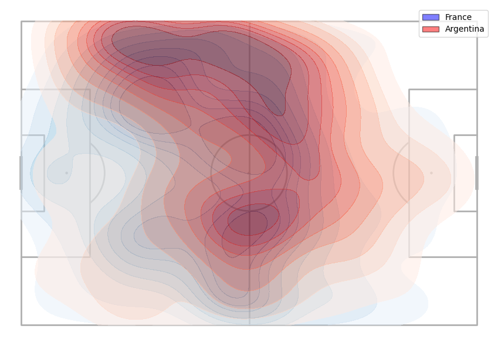

```python
pitch = mpl.Pitch(pitch_type='statsbomb', pitch_length=PITCH_X, pitch_width=PITCH_Y)
fig, ax = pitch.draw(figsize=figsize)
k1 = pitch.kdeplot(france_x, france_y, cmap='Blues', fill=True, levels=10, alpha=0.5, ax=ax)
k2 = pitch.kdeplot(arg_x, arg_y, cmap='Reds', fill=True, levels=10, alpha=0.5, ax=ax)

add_legend(ax=ax, num_elements=2, colors=["blue", "red"], labels=["France", "Argentina"])
plt.savefig("../figures/analysis-01/france_argentina_kde.png", dpi=300, bbox_inches='tight')
plt.show()
```

France seems to have dominated the midfield with noticably darker areas in the centre of midfield. Argentina on the other hand have a higher concentration of actions on the right side of the pitch.

Inspired by [this post](https://karun.in/blog/interactive-passing-networks.html) by Karun Singh, let us plot the average positions of the players in the starting 11.

```python
france_avg_pos = events_handler.compute_avg_pos_for_starting_xi(team_name1)
argentina_avg_pos = events_handler.compute_avg_pos_for_starting_xi(team_name2)
```

```python
starting_xi = events_handler.get_starting_xi_from_events_df()
```

```python
france_avg_pos_with_starting_xi = france_avg_pos.join(starting_xi, on="player_id", how="left")
argentina_avg_pos_with_starting_xi = argentina_avg_pos.join(starting_xi, on="player_id", how="left")
```

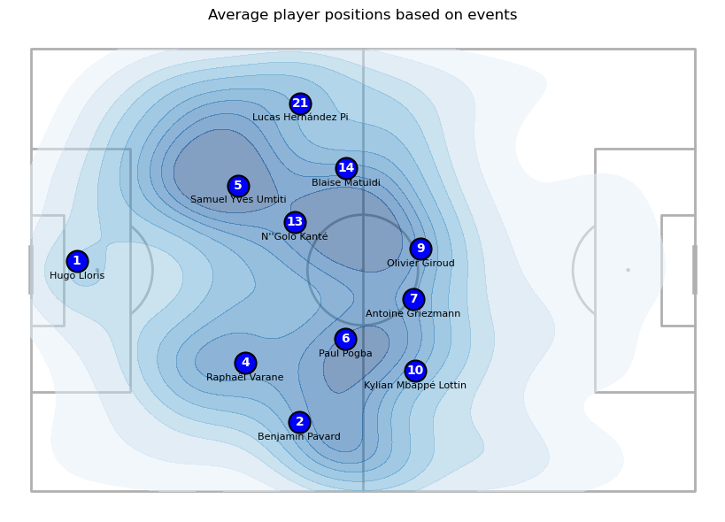

```python
pitch = mpl.Pitch(pitch_type='statsbomb', pitch_length=PITCH_X, pitch_width=PITCH_Y)
fig, ax = pitch.draw(figsize=figsize)
k1 = pitch.kdeplot(france_x, france_y, cmap='Blues', fill=True, levels=10, alpha=0.5, ax=ax)

x, y = france_avg_pos_with_starting_xi["avg_x"].to_numpy(), france_avg_pos_with_starting_xi["avg_y"].to_numpy()
jerseys = france_avg_pos_with_starting_xi["jersey_number"].to_list()
names = france_avg_pos_with_starting_xi["player_name"].to_list()

plot_player_positions(x=x, y=y, jerseys=jerseys, names=names, pitch=pitch, ax=ax, color='blue', fontsize=12, fig_name="../figures/analysis-01/france_avg_pos.png")
```

For France, we indeed see that Blaise Matuidi has dropped inwards from the wing and tucks into the left side of the midfield, forming a three-man midfield with Kante and Pogba. Even though their starting lineup is a 4-2-3-1 on paper, the data shows that they are mainly lining up in a 4-3-3.

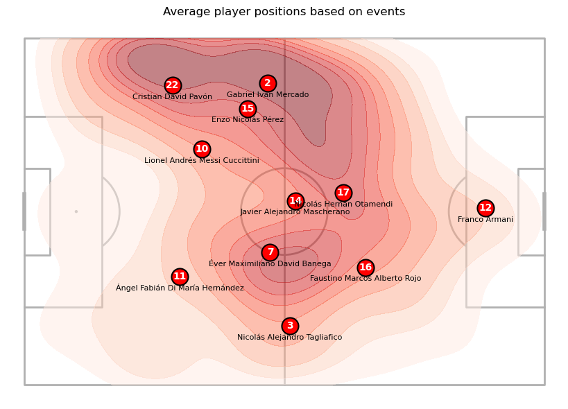

```python
pitch = mpl.Pitch(pitch_type='statsbomb', pitch_length=PITCH_X, pitch_width=PITCH_Y)
fig, ax = pitch.draw(figsize=figsize)
k2 = pitch.kdeplot(arg_x, arg_y, cmap='Reds', fill=True, levels=10, alpha=0.5, ax=ax)

x, y = argentina_avg_pos_with_starting_xi["avg_x"].to_numpy(), argentina_avg_pos_with_starting_xi["avg_y"].to_numpy()
x_inverted = invert_one_orientation(x, PITCH_X)  # Invert x-coordinates for Argentina
y_inverted = invert_one_orientation(y, PITCH_Y)  # Invert y-coordinates for Argentina
jerseys = argentina_avg_pos_with_starting_xi["jersey_number"].to_list()
names = argentina_avg_pos_with_starting_xi["player_name"].to_list()
plot_player_positions(x=x_inverted, y=y_inverted, jerseys=jerseys, names=names, pitch=pitch, ax=ax, color='red', fontsize=12, fig_name="../figures/analysis-01/argentina_avg_pos.png")
```

The event data for Argentina also shows that they have overloaded the right side, pushing up Pavon, Perez and Mercado on the right wing. Even though they line up in a 4-3-3, their average positions resemble something like a 2-4-4 formation. Very unusual! This could also explain why Matuidi was forced to drop further down in midfield.

# Goals and expected goals (xG)

Of course not all shots are equally likely to result in a goal. That is where the expected goals (xG) metric comes in. The xG metric expresses the likelihood of a given shot resulting in a goal based on thousands of past shots with similar features, such as distance, angle, location, and defensive pressure. For instance, Opta's xG model is trained on nealy one million shots from 40 different competitions between 2018-2022. As a result, xG provides a more meaningful reflection of the quality of chances created than raw shot numbers alone.

Let us first have a look at France's shots and goals:

```python
france_shots = france_events.filter(pl.col("type") == "Shot")
france_shots_handler = ShotsHandler(france_shots)

france_shots_x, france_shots_y = france_shots_handler.compute_shot_x_y_locations()
france_goal_x, france_goal_y = france_shots_handler.compute_goal_x_y_locations()
france_shots_xg = france_shots_handler.compute_xg_from_goal_events()
```

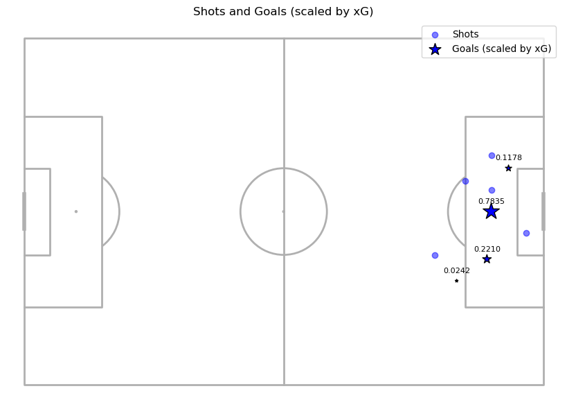

```python
pitch = mpl.Pitch(pitch_type='statsbomb', pitch_length=PITCH_X, pitch_width=PITCH_Y)
fig, ax = pitch.draw(figsize=figsize)

plot_pitch_with_shots(ax, france_shots_x, france_shots_y, france_goal_x, france_goal_y, france_shots_xg, xg_scale_factor, color='blue', fig_name='../figures/analysis-01/france_shots.png')
```

We observe that the majority of France's shots are taken within from a central position within the penalty box, indicating that their attacking approach in the final third of the pitch consistently led to chances in favourable positions. Out of seven shots inside the box, three of them lead to goals, one of which was a penalty scored by Mbappé.

One of the few shots from outside the box was Pavard's half volley with an xG of just 0.0242 based on StatBomb's computations, highlighting just how unlikely it is to score a long-range shot. (This is a goal we will dive deeper into in the next part of the analysis). At the other end of the spectrum, Mbappé's penalty has an enormous xG of 0.7835, meaning a conversion rate of around 78% from this type of shot. When you compare it to the two other goals with more modest xG values of 0.1178 and 0.2210, it clearly highlights the just how decisive and high-quality a penalty kick can be.

Now we plot the same for Argentina.

```python
argentina_shots = arg_events.filter(pl.col("type") == "Shot")
argentina_shots_handler = ShotsHandler(argentina_shots)
argentina_shots_x, argentina_shots_y = invert_orientation(*argentina_shots_handler.compute_shot_x_y_locations(), PITCH_X, PITCH_Y)
argentina_goal_x, argentina_goal_y = invert_orientation(*argentina_shots_handler.compute_goal_x_y_locations(), PITCH_X, PITCH_Y)
argentina_shots_xg = argentina_shots_handler.compute_xg_from_goal_events()
```

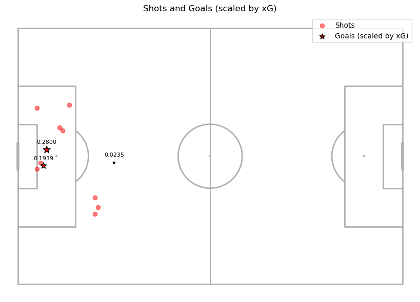

```python
pitch = mpl.Pitch(pitch_type='statsbomb', pitch_length=PITCH_X, pitch_width=PITCH_Y)
fig, ax = pitch.draw(figsize=figsize)

plot_pitch_with_shots(ax, argentina_shots_x, argentina_shots_y, argentina_goal_x, argentina_goal_y, argentina_shots_xg, xg_scale_factor, color='red', fig_name='../figures/analysis-01/argentina_shots.png')
```

Argentina also has a lot of shots within the penalty box, although from considerably worse positions. Out of 8 shots from within the penalty box, they managed to score two. Interestingly, among their shots outside the box, three were taken from almost the same position on the left. They also managed to score an outside-the-box goal with a simiarly low xG value, which was scored by Di Maria.

# Possession patterns

Non-linear relationships in football are everywhere because the game is dynamic, and constrained by spatial and tactical rules. To analyse possession patterns and tactics of France and Argentina, we turn our heads to Gaussian mixture models (GMM) due to their ability to capture the underlying structure in complex, multi-dimensional data.

As the name suggests, Gaussian mixture models are constructed by using a mixture of Gaussian distributions, each weighted with a mixture weight $\pi_k$: $$ p(\bf{x}) = \sum_{k=1}^K \pi_k \, \mathcal{N}(\bf{x} | \bf{\mu}_k, \bf{\Sigma}_k) $$ where $K$ is the number of mixture elements determined from data.

We fit a GMM for both France and Argentina using possession data. We define this as events featuring carries, passes and successful dribbles.

The number of components is determined using the Bayesian Information Criterion (BIC): $$ \text{BIC} = k \ln (n) - 2 \ln{(\hat{L})} $$ where $\hat{L} = \max p(\mathbf{x} | \theta)$ is the maximised value of the likelihood function with parameters $\mathbf{\theta} = \{\mathbf{\pi}, \mathbf{\mu}, \mathbf{\Sigma}\}$.

```python
france_gmm_handler = GMMHandler(france_events, invert_coords=False)
argentina_gmm_handler = GMMHandler(arg_events, invert_coords=True)

france_possesion_events = france_gmm_handler.get_possession_events()
argentina_possesion_events = argentina_gmm_handler.get_possession_events()
```

```python
france_gmm = france_gmm_handler.fit_gmm(france_possesion_events)
```

We fit the GMM on our possesssion data and visualise the shape and size of each Gaussian component projected down onto a 2D football pitch.

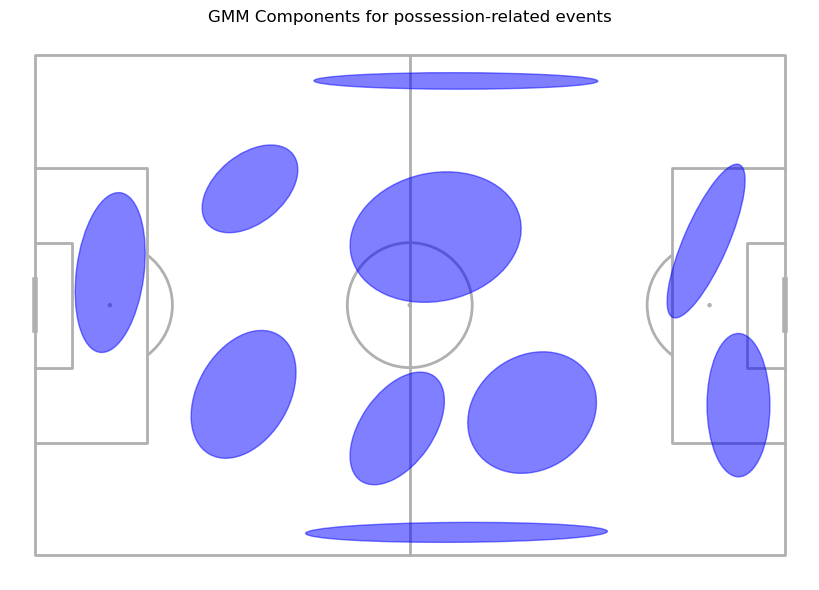

```python
pitch = mpl.Pitch()
fig, ax = pitch.draw(figsize=figsize)
plot_gmm_components(france_gmm, ax, color='blue', fig_name="../figures/analysis-01/france_gmm.png")
```

Using BIC, we get 10 components for our GMM. We can immediately observe that there are two very distinct clusters in the fullback positions on either side of the pitch. This suggests that much of France's possession goes through the wing. Furthermore, there are two prominent clusters in the midfield, coinciding with the average positions of the three midfielders Kante, Matuidi, and Pogba.

Notice the cluster in France's goal keeping area and centreback positions, suggesting a strategy of building up play from the back. In the modern game, it is no longer viable to just let the goalkeeper hoof the ball from the penalty box and hope a teammate wins the ball.

We can also evaluate the probability density function (PDF) of the GMM on the football pitch to quantify how likely the ball ends up at any given area of the pitch during France's possession.

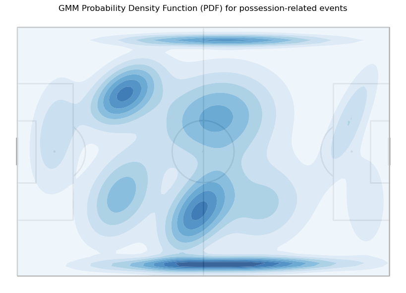

```python
pitch = mpl.Pitch()
fig, ax = pitch.draw(figsize=figsize)
evaluate_and_plot_gmm_pdf(ax, france_gmm, PITCH_X, PITCH_Y, cmap='Blues', fig_name="../figures/analysis-01/france_gmm_pdf.png")
```

The probability densities of our GMM supports our previous observations: much of the possession comes through on the wings and centre of the midfield. Interestingly, a large portion of the possession is also concentrated around the area of the left centreback Umtiti, which indicates he plays a large role in building up play from the back.

```python
argentina_gmm = argentina_gmm_handler.fit_gmm(argentina_possesion_events)
```

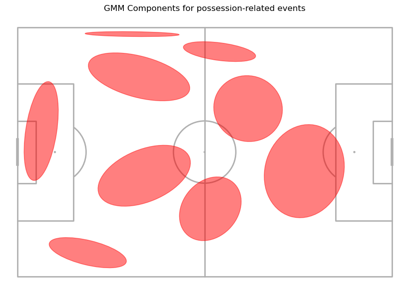

```python
pitch = mpl.Pitch()
fig, ax = pitch.draw(figsize=figsize)
plot_gmm_components(argentina_gmm, ax, color='red', fig_name="../figures/analysis-01/argentina_gmm.png")
```

In Argentina's case, the possession is heavily right-skewed. Much of the possession goes throug the right wing, where we previously saw an overload of four players, including Messi.

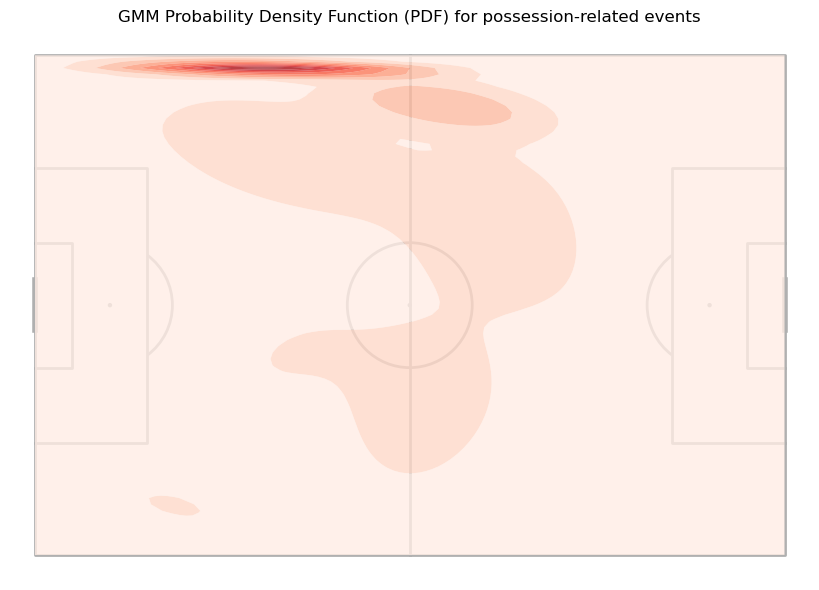

```python
pitch = mpl.Pitch()
fig, ax = pitch.draw(figsize=figsize)
evaluate_and_plot_gmm_pdf(ax, argentina_gmm, PITCH_X, PITCH_Y, cmap='Reds', fig_name="../figures/analysis-01/argentina_gmm_pdf.png")
```

# Sampling possession events from GMM

One neat advantage of using GMMs instead of KDEs is that we can generate samples from our fitted GMM. In this case, we can In this case, we can sample possession events to analyse where France's next events *could* happen given their possession pattern in the match.

This could be useful for opposing football analysts to understand how France plays and keeps posssession.

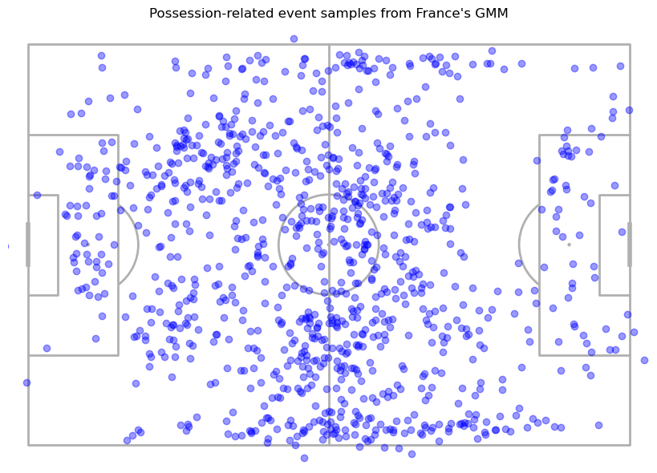

```python
france_samples, _ = france_gmm.sample(1000)

pitch = mpl.Pitch()
fig, ax = pitch.draw(figsize=figsize)
s = pitch.scatter(*france_samples.T, alpha=0.4, color='blue', ax=ax)
plt.title("Possession-related event samples from France's GMM")
plt.savefig("../figures/analysis-01/france_gmm_samples.png", dpi=300, bbox_inches='tight')
plt.show()
```

Now we do the same for Argentina.

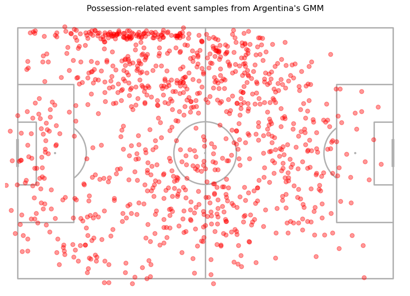

```python
argentina_samples, _ = argentina_gmm.sample(1000) # we don't need to invert here since we already inverted when fitting the GMM

pitch = mpl.Pitch()
fig, ax = pitch.draw(figsize=figsize)
s = pitch.scatter(*argentina_samples.T, alpha=0.4, color='red', ax=ax)
plt.title("Possession-related event samples from Argentina's GMM")
plt.savefig("../figures/analysis-01/argentina_gmm_samples.png", dpi=300, bbox_inches='tight')
plt.show()
```

Pretty cool!